# Analisi serie storica Cisco

### Fabio Palmigiani

Il documento illustra l’analisi della serie storica dei prezzi del titolo Cisco Systems, Inc. (CSCO), dal 2 Gennaio 2018 al 3 aprile 2023. I dati usati sono stati ottenuti da Yahoo Finance (https://finance.yahoo.com/quote/CSCO).

Le librerie usate sono state omesse da questo documento in modo da renderlo più snello. (esse sono comunque visibili sul codice CSCO.R)

## Analisi preliminare

La prima cosa, dopo ovviamente aver importato la serie da Yahoo Finance, è stata dividere il dataset in trainig set e test set. Si è deviso di usare il 90% del dataset per il trainig e il 10% per il test. Successivamente si è costruito un line plot della serie in modo da poter effettuare una prima analisi visiva in maniera più chiara.

```r
# Creo un data frame con i dati desiderati, cioè quelli dal 02 gennaio 2018 al 02 aprile 2023
getSymbols('CSCO')
```

```
## [1] "CSCO"
```

```r
class(CSCO)
```

```
## [1] "xts" "zoo"
```

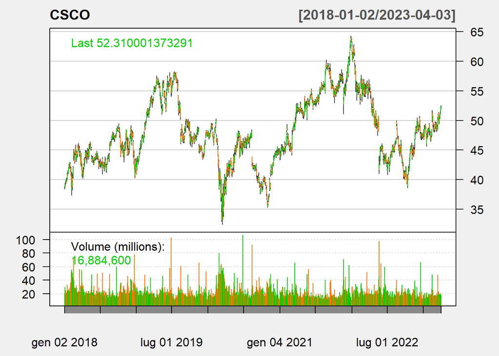

```r
chartSeries(CSCO, subset="2018-01-02::2023-04-03", type="auto", theme=chartTheme('white'))
```

```r
CSCO_df <- data.frame(CSCO)
CSCO.Date <- as.Date(rownames(CSCO_df))
rownames(CSCO_df) <- NULL
CSCO_df <- add_column(CSCO_df, t=1:nrow(CSCO_df), CSCO.Date, .before = 1)

begin <- which(grepl("2018-01-02", CSCO_df$CSCO.Date))
end <- which(grepl("2023-04-03", CSCO_df$CSCO.Date))
Data_df <- CSCO_df[begin:end,]
Data_df <- dplyr::rename(Data_df, Date=CSCO.Date, Open=CSCO.Open, High=CSCO.High,
                         Low=CSCO.Low, Close=CSCO.Close, Volume=CSCO.Volume, Adj.Close=CSCO.Adjusted)

rownames(Data_df) <- NULL
Data_df$t <- 1:nrow(Data_df)
Original_Data <- Data_df
```

```r
# Divido il dataset in trainig set e test set
DtS_length <- nrow(Data_df)
TrnS_length <- floor(DtS_length*0.9)
TstS_length <- DtS_length - TrnS_length
Data_df_train <- Data_df[1:TrnS_length,]
```

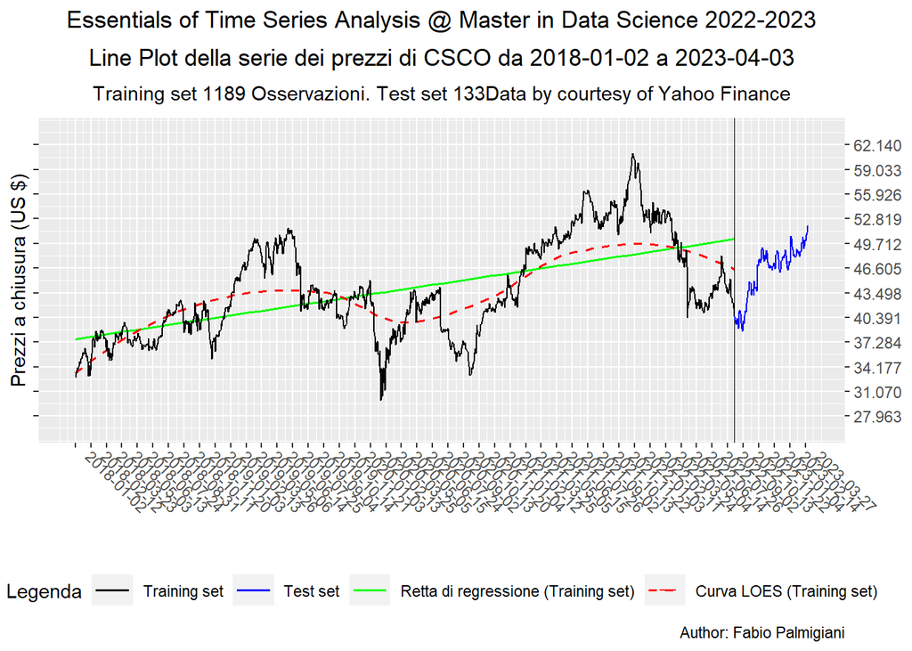

```r
# Line Plot della serie dei prezzi di CSCO
First_Day <- as.character(Data_df$Date[1])
Last_Day <- as.character(Data_df$Date[DtS_length])
title_content <- bquote(atop("Essentials of Time Series Analysis \u0040 Master in Data Science 2022-2023",
                             paste("Line Plot della serie dei prezzi di CSCO da ", .(First_Day), " a ", .(Last_Day))))
subtitle_content <- bquote(paste("Training set ", .(TrnS_length), " Osservazioni. Test set ", .(TstS_length), "Data by courtesy of Yahoo Finance"))
caption_content <- "Author: Fabio Palmigiani"
x_name <- bquote("")
x_breaks_num <- 47
x_breaks_low <- Data_df$t[1]
x_breaks_up <- Data_df$t[DtS_length]
x_binwidth <- floor((x_breaks_up-x_breaks_low)/x_breaks_num)
x_breaks <- seq(from=x_breaks_low, to=x_breaks_up, by=x_binwidth)
if((max(x_breaks)-x_breaks_up)>x_binwidth/2){x_breaks <- c(x_breaks,x_breaks_up)}
x_labs <- Data_df$Date[x_breaks]
J <- 0
x_lims <- c(x_breaks_low-J*x_binwidth, x_breaks_up+J*x_binwidth)
y_name <- bquote("Prezzi a chiusura (US $)")
y_breaks_num <- 10
y_max <- max(na.omit(Data_df$Adj.Close))
y_min <- min(na.omit(Data_df$Adj.Close))
y_binwidth <- round((y_max-y_min)/y_breaks_num, digits=3)
y_breaks_low <- floor((y_min/y_binwidth))*y_binwidth
y_breaks_up <- ceiling((y_max/y_binwidth))*y_binwidth
y_breaks <- round(seq(from=y_breaks_low, to=y_breaks_up, by=y_binwidth),3)
y_labs <- format(y_breaks, scientific=FALSE)
K <- 0.5
y_lims <- c((y_breaks_low-K*y_binwidth), (y_breaks_up+K*y_binwidth))
col_k <- bquote("Training set")
col_b <- bquote("Test set")
col_g <- bquote("Retta di regressione (Training set)")
col_r <- bquote("Curva LOES (Training set)")
leg_labs   <- c(col_k, col_b, col_g, col_r)
leg_cols   <- c("col_k"="black", "col_b"="blue", "col_r"="red", "col_g"="green")
leg_breaks <- c("col_k", "col_b", "col_g", "col_r")
Adj.Close_lp <- ggplot(Data_df) +
  geom_vline(xintercept = Data_df$t[TrnS_length], size=0.3, colour="black") +
  geom_smooth(data=subset(Data_df, Data_df$t <= t[TrnS_length]), alpha=1, linewidth=0.7, linetype="solid",
              aes(x=t, y=Adj.Close, color="col_g"), method="lm" , formula=y~x, se=FALSE, fullrange=FALSE) +
  geom_smooth(data=subset(Data_df, Data_df$t <= t[TrnS_length]), alpha=1, linewidth=0.7, linetype="dashed",
              aes(x=t, y=Adj.Close, color="col_r"), method="loess", formula=y~x, se=FALSE) +
  geom_line(data=subset(Data_df, Data_df$t <= t[TrnS_length]), alpha=1, linewidth=0.5, linetype="solid",
            aes(x=t, y=Adj.Close, color="col_k", group=1)) +
  geom_line(data=subset(Data_df, Data_df$t >= t[TrnS_length]), alpha=1, linewidth=0.5, linetype="solid",
            aes(x=t, y=Adj.Close, color="col_b", group=1)) +
  scale_x_continuous(name=x_name, breaks=x_breaks, label=x_labs, limits=x_lims) +
  scale_y_continuous(name=y_name, breaks=y_breaks, labels=NULL, limits=y_lims,
                     sec.axis = sec_axis(~., breaks=y_breaks, labels=y_labs)) +
  ggtitle(title_content) +
  labs(subtitle=subtitle_content, caption=caption_content) +
  scale_colour_manual(name="Legenda", labels=leg_labs, values=leg_cols, breaks=leg_breaks,
                      guide=guide_legend(override.aes=list(linetype=c("solid", "solid", "solid", "dashed")))) +
  theme(plot.title=element_text(hjust=0.5),
        plot.subtitle=element_text(hjust=0.5),
        axis.text.x = element_text(angle=-45, vjust=1, hjust=-0.3),
        legend.key.width = unit(0.8,"cm"), legend.position="bottom")
plot(Adj.Close_lp)
```

Come prevedibile da una serie finanziaria il line plot non evidenzia un trend ben definito. Questo è confermato dalla LOESS, che si discosta dalla retta di regressione. Non sembra essere presente neppure una componente stagionale.

Per studiare gli autocorrelogrammi si è deciso di scegliere il numero di lag consigliato da Hyndman (ceiling(min(10, T/4))), in quanto la serie non sembra presentare una componente stagionale.

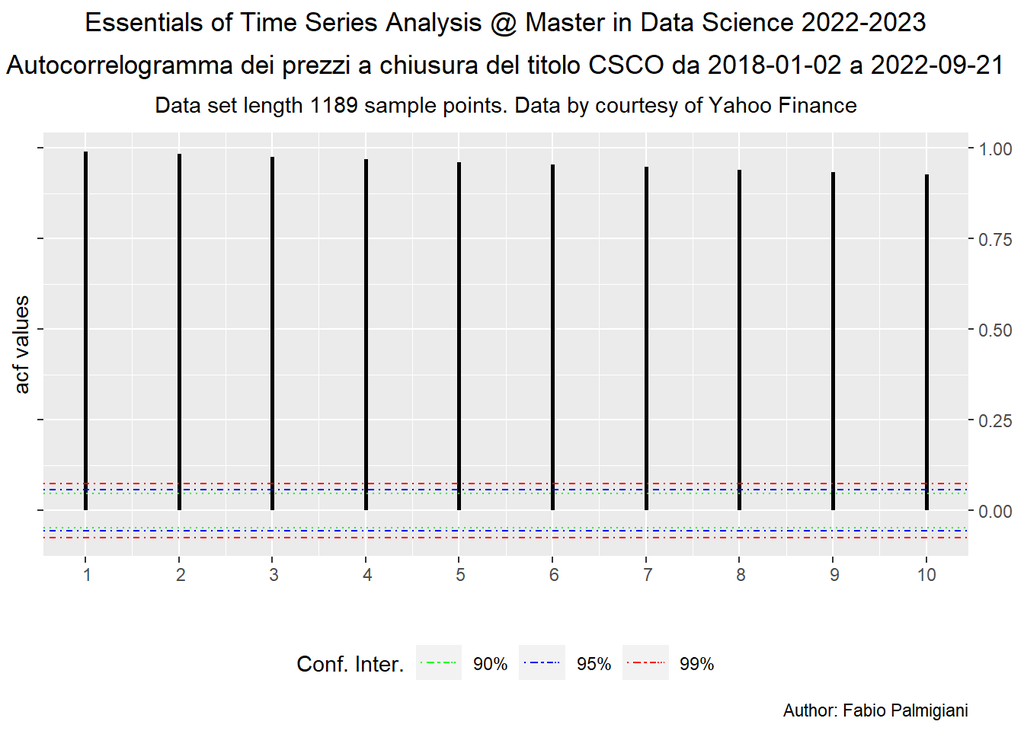

```r
# AUTOCORRELOGRAMMA
y <-  Data_df_train$Adj.Close
T <- length(y)
maxlag <- ceiling(min(10, T/4))
Aut_Fun_y <- acf(y, lag.max=maxlag, type="correlation", plot=FALSE)
ci_90 <- qnorm((1+0.90)/2)/sqrt(T)
ci_95 <- qnorm((1+0.95)/2)/sqrt(T)
ci_99 <- qnorm((1+0.99)/2)/sqrt(T)
Plot_Aut_Fun_y <- data.frame(lag=Aut_Fun_y$lag, acf=Aut_Fun_y$acf)
First_Day <- as.character(Data_df_train$Date[1])
Last_Day <- as.character(Data_df_train$Date[T])
title_content <- bquote(atop("Essentials of Time Series Analysis \u0040 Master in Data Science 2022-2023",
                             paste("Autocorrelogramma dei prezzi a chiusura del titolo CSCO da ", .(First_Day), " a ", .(Last_Day))))
subtitle_content <- bquote(paste("Data set length ", .(T), " sample points. Data by courtesy of Yahoo Finance"))
caption_content <- "Author: Fabio Palmigiani"
x_name <- bquote("lags")
x_breaks <- Aut_Fun_y$lag
x_labs <- format(x_breaks, scientific=FALSE)
ggplot(Plot_Aut_Fun_y, aes(x=lag, y=acf))+
  geom_segment(aes(x=lag, y=rep(0,length(lag)), xend=lag, yend=acf), linewidth=1, col="black") +
  geom_hline(aes(yintercept=-ci_90, color="CI_90"), show.legend=TRUE, lty=3) +
  geom_hline(aes(yintercept=ci_90, color="CI_90"), lty=3) +
  geom_hline(aes(yintercept=ci_95, color="CI_95"), show.legend=TRUE, lty=4)+
  geom_hline(aes(yintercept=-ci_95, color="CI_95"), lty=4) +
  geom_hline(aes(yintercept=-ci_99, color="CI_99"), show.legend=TRUE, lty=4) +
  geom_hline(aes(yintercept=ci_99, color="CI_99"), lty=4) +
  scale_x_continuous(name="", breaks=x_breaks, label=x_labs) +
  scale_y_continuous(name="acf values", breaks=waiver(), labels=NULL,
                     sec.axis=sec_axis(~., breaks=waiver(), labels=waiver())) +
  scale_color_manual(name="Conf. Inter.", labels=c("90%","95%","99%"),
                     values=c(CI_90="green", CI_95="blue", CI_99="red")) +
  ggtitle(title_content) +
  labs(subtitle=subtitle_content, caption=caption_content) +
  theme(plot.title=element_text(hjust=0.5),
        plot.subtitle=element_text(hjust= 0.5),
        plot.caption=element_text(hjust=1.0),
        legend.key.width=unit(0.8,"cm"), legend.position="bottom")
```

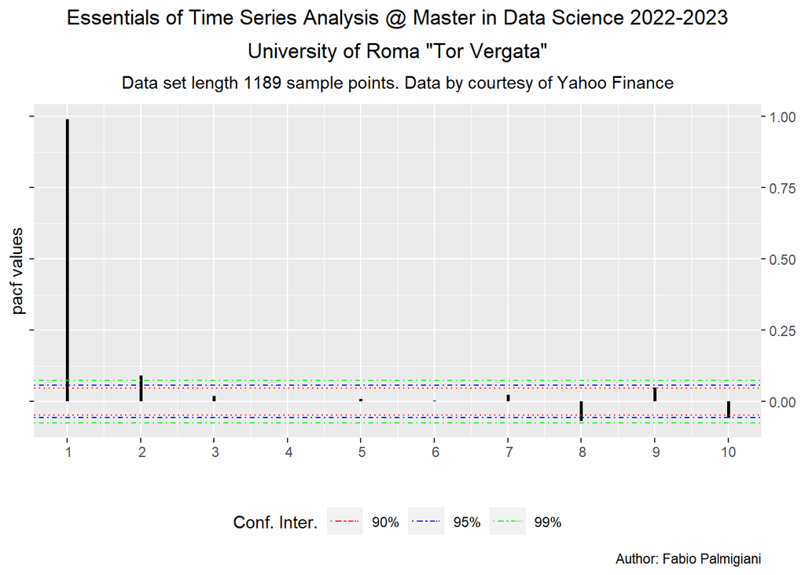

```r
# AUTOCORRELOGRAMMA PARZIALE
y <-  Data_df_train$Adj.Close
T <- length(y)
maxlag <- ceiling(min(10, T/4))
Part_Aut_Fun_y <- pacf(y, lag.max=maxlag, type="correlation", plot=FALSE)
ci_90 <- qnorm((1+0.90)/2)/sqrt(T)
ci_95 <- qnorm((1+0.95)/2)/sqrt(T)
ci_99 <- qnorm((1+0.99)/2)/sqrt(T)
Plot_Part_Aut_Fun_y <- data.frame(lag=Part_Aut_Fun_y$lag, pacf=Part_Aut_Fun_y$acf)
First_Day <- as.character(Data_df_train$Date[1])
Last_Day <- as.character(Data_df_train$Date[nrow(Data_df_train)])
x_name <- bquote("lags")
x_breaks <- Aut_Fun_y$lag
x_labs <- format(x_breaks, scientific=FALSE)
title_content <- bquote(atop("Essentials of Time Series Analysis \u0040 Master in Data Science 2022-2023",
                             paste("University of Roma \"Tor Vergata\""),
                             paste("Autocorrelogramma parziale dei prezzi a chiusura del titolo CSCO da ", .(First_Day), " a ", .(Last_Day))))
subtitle_content <- bquote(paste("Data set length ", .(T), " sample points. Data by courtesy of Yahoo Finance"))
caption_content <- "Author: Fabio Palmigiani"
ggplot(Plot_Part_Aut_Fun_y, aes(x=lag, y=pacf)) +
  geom_segment(aes(x=lag, y=rep(0,length(lag)), xend=lag, yend=pacf), size = 1, col="black") +
  geom_hline(aes(yintercept=-ci_90, color="CI_90"), show.legend = TRUE, lty=3) +
  geom_hline(aes(yintercept=ci_90, color="CI_90"), lty=3) +
  geom_hline(aes(yintercept=ci_95, color="CI_95"), show.legend = TRUE, lty=4) +
  geom_hline(aes(yintercept=-ci_95, color="CI_95"), lty=4) +
  geom_hline(aes(yintercept=-ci_99, color="CI_99"), show.legend = TRUE, lty=4) +
  geom_hline(aes(yintercept=ci_99, color="CI_99"), lty=4) +
  scale_x_continuous(name="", breaks=x_breaks, label=x_labs) +
  scale_y_continuous(name="pacf values", breaks=waiver(), labels=NULL,
                     sec.axis = sec_axis(~., breaks=waiver(), labels=waiver())) +
  scale_color_manual(name="Conf. Inter.", labels=c("90%","95%","99%"),
                     values=c(CI_90="red", CI_95="blue", CI_99="green")) +
  ggtitle(title_content) +
  labs(subtitle=subtitle_content, caption=caption_content) +
  theme(plot.title=element_text(hjust = 0.5),
        plot.subtitle=element_text(hjust =  0.5),
        plot.caption = element_text(hjust = 1.0),
        legend.key.width = unit(0.8,"cm"), legend.position="bottom")
```

Dai due autocorrelogrammi è evidente che i prezzi sono autocorrelati.

Si è passato quindi a studiare la serie dei rendimenti logaritmici.

## Studio della serie dei rendimenti logaritmici

Una volta ottenuti i rendimenti logaritmici della serie si sono effettuati gli stessi passaggi fatti in precedenza, cioè si è diviso il dataset in trainig set e test set.

```r
# CALCOLO DEI RENDIMENTI LOGARITMICI
CSCO_df <- add_column(CSCO_df, CSCO.Adjusted.log=log(CSCO_df$CSCO.Adjusted),
                      CSCO.Adjusted.log.ret=c(NA,diff(log(CSCO_df$CSCO.Adjusted), lag=1, difference=1)),
                      .after="CSCO.Adjusted")

begin <- which(grepl("2018-01-02", CSCO_df$CSCO.Date))
end <- which(grepl("2023-04-03", CSCO_df$CSCO.Date))
Data_df <- CSCO_df[begin:end,]
Data_df <- dplyr::rename(Data_df, Date=CSCO.Date, Open=CSCO.Open, High=CSCO.High,
                         Low=CSCO.Low, Close=CSCO.Close, Volume=CSCO.Volume, Adj.Close=CSCO.Adjusted,
                         Adj.Close.log=CSCO.Adjusted.log, Adj.Close.log.ret=CSCO.Adjusted.log.ret)

rownames(Data_df) <- NULL
Data_df$t <- 1:nrow(Data_df)

# COSTRIZIONE TRAINIG SET
Data_df_train <- Data_df[1:TrnS_length,]
y <- Data_df_train$Adj.Close.log.ret
```

è utile mostrare anche lo scatter plot e il line plot della serie dei rendimenti logarimici

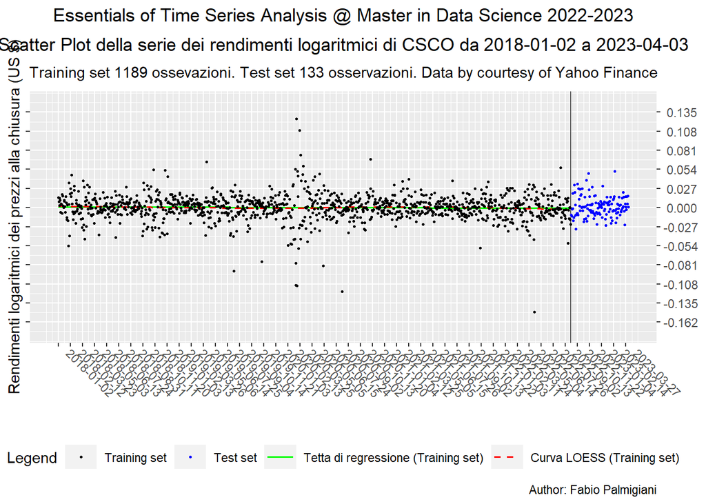

```r
#SCATTER PLOT
First_Day <- as.character(Data_df$Date[1])
Last_Day <- as.character(Data_df$Date[DtS_length])
title_content <- bquote(atop("Essentials of Time Series Analysis \u0040 Master in Data Science 2022-2023",
                             paste("Scatter Plot della serie dei rendimenti logaritmici di CSCO da ", .(First_Day), " a ", .(Last_Day))))
subtitle_content <- bquote(paste("Training set ", .(TrnS_length), " ossevazioni. Test set ", .(TstS_length), " osservazioni. Data by courtesy of Yahoo Finance"))
caption_content <- "Author: Fabio Palmigiani"
x_name <- bquote("")
x_breaks_num <- 47
x_breaks_low <- Data_df$t[1]
x_breaks_up <- Data_df$t[DtS_length]
x_binwidth <- floor((x_breaks_up-x_breaks_low)/x_breaks_num)
x_breaks <- seq(from=x_breaks_low, to=x_breaks_up, by=x_binwidth)
if((max(x_breaks)-x_breaks_up)>x_binwidth/2){x_breaks <- c(x_breaks,x_breaks_up)}
x_labs <- Data_df$Date[x_breaks]
J <- 0
x_lims <- c(x_breaks_low-J*x_binwidth, x_breaks_up+J*x_binwidth)
y_name <- bquote("Rendimenti logaritmici dei prezzi alla chiusura (US $)")
y_breaks_num <- 10
y_max <- max(na.omit(Data_df$Adj.Close.log.ret))
y_min <- min(na.omit(Data_df$Adj.Close.log.ret))
y_binwidth <- round((y_max-y_min)/y_breaks_num, digits=3)
y_breaks_low <- floor((y_min/y_binwidth))*y_binwidth
y_breaks_up <- ceiling((y_max/y_binwidth))*y_binwidth
y_breaks <- round(seq(from=y_breaks_low, to=y_breaks_up, by=y_binwidth),3)
y_labs <- format(y_breaks, scientific=FALSE)
K <- 0.5
y_lims <- c((y_breaks_low-K*y_binwidth), (y_breaks_up+K*y_binwidth))
col_k <- bquote("Training set")
col_b <- bquote("Test set")
col_g <- bquote("Tetta di regressione (Training set)")
col_r <- bquote("Curva LOESS (Training set)")
leg_labs   <- c(col_k, col_b, col_g, col_r)
leg_cols   <- c("col_k"="black", "col_b"="blue", "col_r"="red", "col_g"="green")
leg_breaks <- c("col_k", "col_b", "col_g", "col_r")
Adj.Close.log.ret_sp <- ggplot(Data_df) +
  geom_vline(xintercept = Data_df$t[TrnS_length], linewidth=0.3, colour="black") +
  geom_smooth(data=subset(Data_df, Data_df$t <= t[TrnS_length]), alpha=1, linewidth=0.7, linetype="solid",
              aes(x=t, y=Adj.Close.log.ret, color="col_g"), method="lm", formula=y~x, se=FALSE, fullrange=FALSE) +
  geom_smooth(data=subset(Data_df, Data_df$t <= t[TrnS_length]), alpha=1, linewidth=0.7, linetype="dashed",
              aes(x=t, y=Adj.Close.log.ret, color="col_r"), method = "loess", formula = y ~ x, se=FALSE) +
  geom_point(data=subset(Data_df, Data_df$t <= t[TrnS_length]), alpha=1, size=0.5, shape=19,
             aes(x=t, y=Adj.Close.log.ret, color="col_k")) +
  geom_point(data=subset(Data_df, Data_df$t > t[TrnS_length]), alpha=1, size=0.5, shape=19,
             aes(x=t, y=Adj.Close.log.ret, color="col_b")) +
  scale_x_continuous(name=x_name, breaks=x_breaks, label=x_labs, limits=x_lims) +
  scale_y_continuous(name=y_name, breaks=y_breaks, labels=NULL, limits=y_lims,
                     sec.axis = sec_axis(~., breaks=y_breaks, labels=y_labs)) +
  ggtitle(title_content) +
  labs(subtitle=subtitle_content, caption=caption_content) +
  scale_colour_manual(name="Legend", labels=leg_labs, values=leg_cols, breaks=leg_breaks,
                      guide=guide_legend(override.aes=list(shape=c(19,19,NA,NA),
                                                           linetype=c("blank", "blank", "solid", "dashed")))) +
  theme(plot.title=element_text(hjust=0.5),
        plot.subtitle=element_text(hjust= 0.5),
        axis.text.x = element_text(angle=-45, vjust=1, hjust=-0.3),
        legend.key.width = unit(0.8,"cm"), legend.position="bottom")
plot(Adj.Close.log.ret_sp)
```

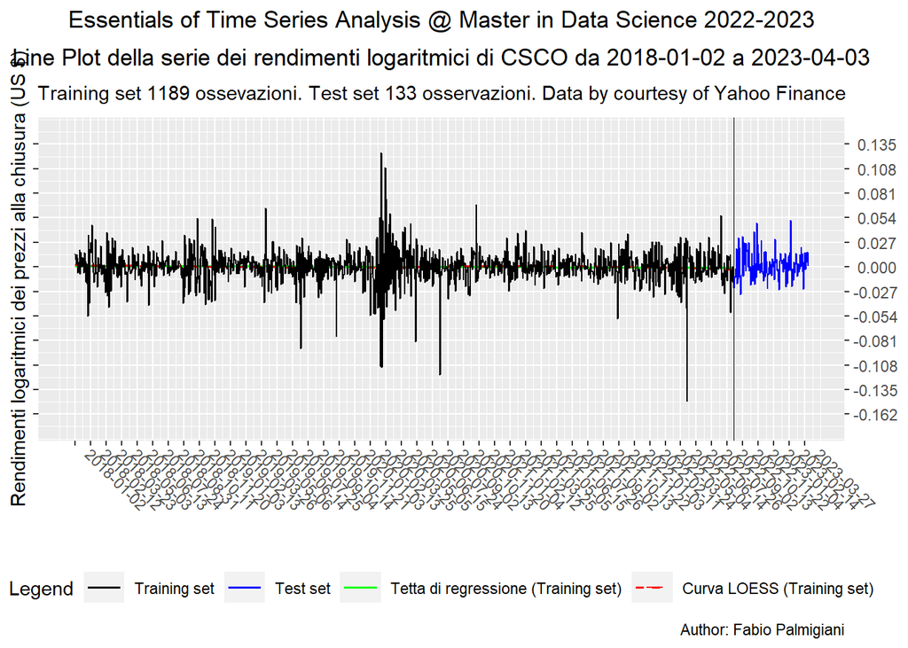

```r
# LINE PLOT
title_content <- bquote(atop("Essentials of Time Series Analysis \u0040 Master in Data Science 2022-2023",
                             paste("Line Plot della serie dei rendimenti logaritmici di CSCO da ", .(First_Day), " a ", .(Last_Day))))
Adj.Close.ret_lp <- ggplot(Data_df) +
  geom_vline(xintercept = Data_df$t[TrnS_length], linewidth=0.3, colour="black") +
  geom_smooth(data=subset(Data_df, Data_df$t <= t[TrnS_length]), alpha=1, linewidth=0.7, linetype="solid",
              aes(x=t, y=Adj.Close.log.ret, color="col_g"), method="lm", formula=y~x, se=FALSE, fullrange=FALSE) +
  geom_smooth(data=subset(Data_df, Data_df$t <= t[TrnS_length]), alpha=1, linewidth=0.7, linetype="dashed",
              aes(x=t, y=Adj.Close.log.ret, color="col_r"), method = "loess", formula = y ~ x, se=FALSE) +
  geom_line(data=subset(Data_df, Data_df$t <= t[TrnS_length]), alpha=1, linewidth=0.5, linetype="solid",
            aes(x=t, y=Adj.Close.log.ret, color="col_k", group=1)) +
  geom_line(data=subset(Data_df, Data_df$t >= t[TrnS_length]), alpha=1, linewidth=0.5, linetype="solid",
            aes(x=t, y=Adj.Close.log.ret, color="col_b", group=1)) +
  scale_x_continuous(name=x_name, breaks=x_breaks, label=x_labs, limits=x_lims) +
  scale_y_continuous(name=y_name, breaks=y_breaks, labels=NULL, limits=y_lims,
                     sec.axis = sec_axis(~., breaks=y_breaks, labels=y_labs)) +
  ggtitle(title_content) +
  labs(subtitle=subtitle_content, caption=caption_content) +
  scale_colour_manual(name="Legend", labels=leg_labs, values=leg_cols, breaks=leg_breaks,
                      guide=guide_legend(override.aes=list(linetype=c("solid", "solid", "solid", "dashed")))) +
  theme(plot.title=element_text(hjust=0.5),
        plot.subtitle=element_text(hjust=0.5),
        axis.text.x = element_text(angle=-45, vjust=1, hjust=-0.3),
        legend.key.width = unit(0.8,"cm"), legend.position="bottom")
plot(Adj.Close.ret_lp)
```

Dai grafici si nota che la loess è quasi coincidente con la retta di regressione, questo ci fa pensare che i rendimenti siano mediamente nulli. Inoltre, si direbbe che la variabilità sia costante nel tempo a meno di alcuni picchi. Resta però complicato stabilirlo dal solo grafico, quindi si è desiso di rivolgersi ai test di Breush-Pagan e White per poter affermare che la serie sia omoshedastica.

```r
Data_df <- data.frame(x=Data_df_train$t, y=y)
Kurt_Gauss <- DescTools::Kurt(x=y, weights = NULL, na.rm = TRUE, method = 2, conf.level = 0.95, ci.type ="classic")
show(Kurt_Gauss)
```

```
##   kurtosis     lwr.ci     upr.ci
## 10.4265815 -0.2778773  0.2778773
```

```r
BP <- lmtest::bptest(formula = y~x, varformula = NULL, studentize = TRUE, data=Data_df)
show(BP)
```

```
##
##  studentized Breusch-Pagan test
##
## data:  y ~ x
## BP = 0.0021954, df = 1, p-value = 0.9626
```

```r
var.formula <- ~ x+I(x^2)
W <- lmtest::bptest(formula = y ~ x, varformula = var.formula, studentize = TRUE, data=Data_df)
show(W)
```

```
##
##  studentized Breusch-Pagan test
##
## data:  y ~ x
## BP = 3.7925, df = 2, p-value = 0.1501
```

Dai test si è avuto la conferma che la serie è omoschedasticha. Si è proceduto quindi con lo studio della stazionarietà dei rendimenti logaritmici, effettuando i test KPSS.

```r
y_KPSS_ur_tau_nil <- ur.kpss(y, type="tau", lags="nil")
summary(y_KPSS_ur_tau_nil)
```

```
##
## #######################
## # KPSS Unit Root Test #
## #######################
##
## Test is of type: tau with 0 lags.
##
## Value of test-statistic is: 0.0456
##
## Critical value for a significance level of:
##                 10pct  5pct 2.5pct  1pct
## critical values 0.119 0.146  0.176 0.216
```

```r
y_KPSS_ur_tau_short <- ur.kpss(y, type="tau", lags="short")
summary(y_KPSS_ur_tau_short)
```

```
##
## #######################
## # KPSS Unit Root Test #
## #######################
##
## Test is of type: tau with 7 lags.
##
## Value of test-statistic is: 0.0598
##
## Critical value for a significance level of:
##                 10pct  5pct 2.5pct  1pct
## critical values 0.119 0.146  0.176 0.216
```

```r
y_KPSS_ur_tau_long <- ur.kpss(y, type="tau", lags="long")
summary(y_KPSS_ur_tau_long)
```

```
##
## #######################
## # KPSS Unit Root Test #
## #######################
##
## Test is of type: tau with 22 lags.
##
## Value of test-statistic is: 0.0594
##
## Critical value for a significance level of:
##                 10pct  5pct 2.5pct  1pct
## critical values 0.119 0.146  0.176 0.216
```

Tutti e tre i test non hanno permesso di rigettare l’ipotesi nulla di stazionarietà, quindi è stato possibile affermare che la serie dei rendimenti logarimici sia stazionaria.

Per studiare l’autocorrelazione dei rendimenti logaritmici si è mostrato l’autocorrelogramma e l’autocorrelogramma parziale.

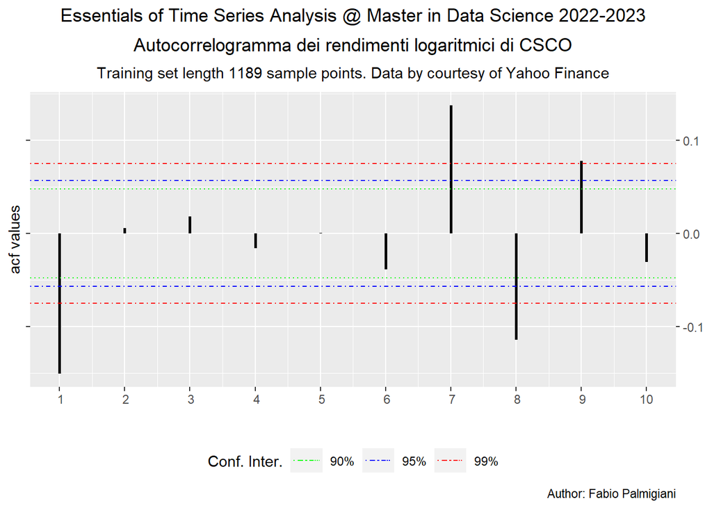

```r
# AUTOCORRELOGRAMMA RENDIMENTI LOGARITMICI
y <- Data_df_train$Adj.Close.log.ret
T <- length(y)
maxlag <- ceiling(min(10, T/4))
Aut_Fun_y <- acf(y, lag.max=maxlag, type="correlation", plot=FALSE)
ci_90 <- qnorm((1+0.90)/2)/sqrt(T)
ci_95 <- qnorm((1+0.95)/2)/sqrt(T)
ci_99 <- qnorm((1+0.99)/2)/sqrt(T)
Plot_Aut_Fun_y <- data.frame(lag=Aut_Fun_y$lag, acf=Aut_Fun_y$acf)
First_Day <- as.character(Data_df_train$Date[1])
Last_Day <- as.character(Data_df_train$Date[T])
title_content <- bquote(atop("Essentials of Time Series Analysis \u0040 Master in Data Science 2022-2023",
                             paste("Autocorrelogramma dei rendimenti logaritmici di CSCO")))
subtitle_content <- bquote(paste("Training set length ", .(TrnS_length), " sample points. Data by courtesy of Yahoo Finance"))
caption_content <- "Author: Fabio Palmigiani"
x_name <- bquote("lags")
x_breaks <- Aut_Fun_y$lag
x_labs <- format(x_breaks, scientific=FALSE)
ggplot(Plot_Aut_Fun_y, aes(x=lag, y=acf))+
  geom_segment(aes(x=lag, y=rep(0,length(lag)), xend=lag, yend=acf), linewidth=1, col="black") +
  geom_hline(aes(yintercept=-ci_90, color="CI_90"), show.legend=TRUE, lty=3) +
  geom_hline(aes(yintercept=ci_90, color="CI_90"), lty=3) +
  geom_hline(aes(yintercept=ci_95, color="CI_95"), show.legend=TRUE, lty=4)+
  geom_hline(aes(yintercept=-ci_95, color="CI_95"), lty=4) +
  geom_hline(aes(yintercept=-ci_99, color="CI_99"), show.legend=TRUE, lty=4) +
  geom_hline(aes(yintercept=ci_99, color="CI_99"), lty=4) +
  scale_x_continuous(name="", breaks=x_breaks, label=x_labs) +
  scale_y_continuous(name="acf values", breaks=waiver(), labels=NULL,
                     sec.axis=sec_axis(~., breaks=waiver(), labels=waiver())) +
  scale_color_manual(name="Conf. Inter.", labels=c("90%","95%","99%"),
                     values=c(CI_90="green", CI_95="blue", CI_99="red")) +
  ggtitle(title_content) +
  labs(subtitle=subtitle_content, caption=caption_content) +
  theme(plot.title=element_text(hjust=0.5),
        plot.subtitle=element_text(hjust= 0.5),
        plot.caption=element_text(hjust=1.0),
        legend.key.width=unit(0.8,"cm"), legend.position="bottom")
```

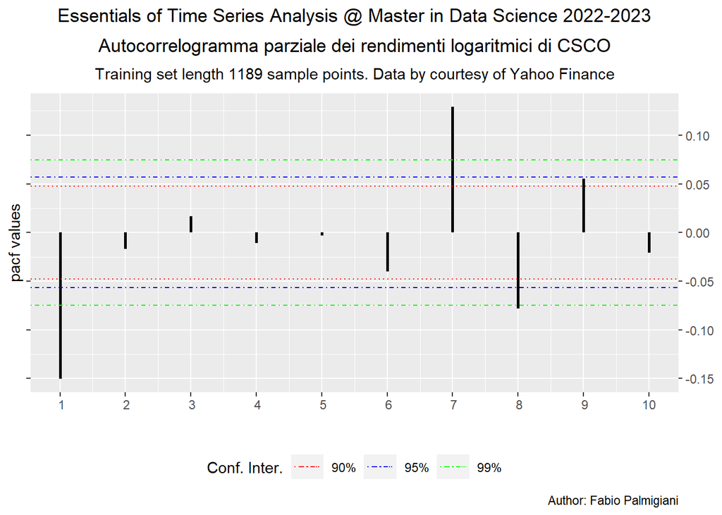

```r
# AUTOCORRELOGRAMMA PARZIALE RENDIMENTI LOGARITMICI
Part_Aut_Fun_y <- pacf(y, lag.max=maxlag, type="correlation", plot=FALSE)
ci_90 <- qnorm((1+0.90)/2)/sqrt(T)
ci_95 <- qnorm((1+0.95)/2)/sqrt(T)
ci_99 <- qnorm((1+0.99)/2)/sqrt(T)
Plot_Part_Aut_Fun_y <- data.frame(lag=Part_Aut_Fun_y$lag, pacf=Part_Aut_Fun_y$acf)
First_Day <- as.character(Data_df_train$Date[1])
Last_Day <- as.character(Data_df_train$Date[nrow(Data_df_train)])
x_name <- bquote("lags")
x_breaks <- Aut_Fun_y$lag
x_labs <- format(x_breaks, scientific=FALSE)
title_content <- bquote(atop("Essentials of Time Series Analysis \u0040 Master in Data Science 2022-2023",
                             paste("Autocorrelogramma parziale dei rendimenti logaritmici di CSCO")))
subtitle_content <- bquote(paste("Training set length ", .(TrnS_length), " sample points. Data by courtesy of Yahoo Finance"))
caption_content <- "Author: Fabio Palmigiani"
ggplot(Plot_Part_Aut_Fun_y, aes(x=lag, y=pacf)) +
  geom_segment(aes(x=lag, y=rep(0,length(lag)), xend=lag, yend=pacf), size = 1, col="black") +
  geom_hline(aes(yintercept=-ci_90, color="CI_90"), show.legend = TRUE, lty=3) +
  geom_hline(aes(yintercept=ci_90, color="CI_90"), lty=3) +
  geom_hline(aes(yintercept=ci_95, color="CI_95"), show.legend = TRUE, lty=4) +
  geom_hline(aes(yintercept=-ci_95, color="CI_95"), lty=4) +
  geom_hline(aes(yintercept=-ci_99, color="CI_99"), show.legend = TRUE, lty=4) +
  geom_hline(aes(yintercept=ci_99, color="CI_99"), lty=4) +
  scale_x_continuous(name="", breaks=x_breaks, label=x_labs) +
  scale_y_continuous(name="pacf values", breaks=waiver(), labels=NULL,
                     sec.axis = sec_axis(~., breaks=waiver(), labels=waiver())) +
  scale_color_manual(name="Conf. Inter.", labels=c("90%","95%","99%"),
                     values=c(CI_90="red", CI_95="blue", CI_99="green")) +
  ggtitle(title_content) +
  labs(subtitle=subtitle_content, caption=caption_content) +
  theme(plot.title=element_text(hjust = 0.5),
        plot.subtitle=element_text(hjust =  0.5),
        plot.caption = element_text(hjust = 1.0),
        legend.key.width = unit(0.8,"cm"), legend.position="bottom")
```

entrambi i grafici presentano dei picchi molto accentuati, quindi è stato possibile affermare con forza che la serie dei rendimenti logaritmici è autocerrelata.

A questo punto restava da capire che tipo di processo può spiegare il comportamento dei rendimenti logaritmici. Quindi si è deciso di effettuare i test di Dickey-Fuller con diverse ipotesi alternative: * Il processo non è autoregressivo senza trend lineare e drift * Il processo non è autoregressivo con drift e senza trend lineare * Il processo non è autoregressivo con trend lineare e drift

```r
l <- 0
y_ADF_ur.df_trend_0_lags <- ur.df(y, type="trend", lags=l, selectlags ="Fixed")
summary(y_ADF_ur.df_trend_0_lags)
```

```
##
## ###############################################
## # Augmented Dickey-Fuller Test Unit Root Test #
## ###############################################
##
## Test regression trend
##
##
## Call:
## lm(formula = z.diff ~ z.lag.1 + 1 + tt)
##
## Residuals:
##       Min        1Q    Median        3Q       Max
## -0.153880 -0.007794  0.000411  0.009020  0.108633
##
## Coefficients:
##               Estimate Std. Error t value Pr(>|t|)
## (Intercept)  1.229e-03  1.072e-03   1.146    0.252
## z.lag.1     -1.151e+00  2.873e-02 -40.078   <2e-16 ***
## tt          -1.716e-06  1.562e-06  -1.098    0.272
## ---
## Signif. codes:  0 '***' 0.001 '**' 0.01 '*' 0.05 '.' 0.1 ' ' 1
##
## Residual standard error: 0.01846 on 1185 degrees of freedom
## Multiple R-squared:  0.5755, Adjusted R-squared:  0.5747
## F-statistic: 803.1 on 2 and 1185 DF,  p-value: < 2.2e-16
##
##
## Value of test-statistic is: -40.0778 535.4109 803.1145
##
## Critical values for test statistics:
##       1pct  5pct 10pct
## tau3 -3.96 -3.41 -3.12
## phi2  6.09  4.68  4.03
## phi3  8.27  6.25  5.34
```

```r
long_lags <- floor(12*(length(y)/100)^(1/4))
y_ADF_ur.df_trend_long_lags <- ur.df(y, type="trend", lags=long_lags, selectlags ="Fixed")
summary(y_ADF_ur.df_trend_long_lags)
```

```
##
## ###############################################
## # Augmented Dickey-Fuller Test Unit Root Test #
## ###############################################
##
## Test regression trend
##
##
## Call:
## lm(formula = z.diff ~ z.lag.1 + 1 + tt + z.diff.lag)
##
## Residuals:
##       Min        1Q    Median        3Q       Max
## -0.150035 -0.007979  0.000599  0.009542  0.097013
##
## Coefficients:
##                Estimate Std. Error t value Pr(>|t|)
## (Intercept)   1.121e-03  1.112e-03   1.009   0.3132
## z.lag.1      -1.213e+00  1.593e-01  -7.617 5.43e-14 ***
## tt           -1.562e-06  1.601e-06  -0.976   0.3294
## z.diff.lag1   8.227e-02  1.554e-01   0.530   0.5965
## z.diff.lag2   5.027e-02  1.515e-01   0.332   0.7401
## z.diff.lag3   6.762e-02  1.476e-01   0.458   0.6470
## z.diff.lag4   5.527e-02  1.439e-01   0.384   0.7011
## z.diff.lag5   4.277e-02  1.404e-01   0.305   0.7607
## z.diff.lag6   3.156e-02  1.368e-01   0.231   0.8176
## z.diff.lag7   1.388e-01  1.332e-01   1.042   0.2974
## z.diff.lag8   7.738e-02  1.289e-01   0.600   0.5485
## z.diff.lag9   1.152e-01  1.246e-01   0.925   0.3551
## z.diff.lag10  9.703e-02  1.199e-01   0.809   0.4186
## z.diff.lag11  8.524e-02  1.154e-01   0.739   0.4602
## z.diff.lag12  1.090e-01  1.104e-01   0.987   0.3239
## z.diff.lag13  7.632e-02  1.054e-01   0.724   0.4692
## z.diff.lag14  1.039e-01  1.003e-01   1.035   0.3009
## z.diff.lag15  1.047e-01  9.458e-02   1.107   0.2685
## z.diff.lag16  1.917e-01  8.910e-02   2.152   0.0316 *
## z.diff.lag17  1.702e-01  8.201e-02   2.076   0.0381 *
## z.diff.lag18  1.643e-01  7.435e-02   2.209   0.0274 *
## z.diff.lag19  1.283e-01  6.608e-02   1.942   0.0523 .
## z.diff.lag20  8.251e-02  5.670e-02   1.455   0.1459
## z.diff.lag21  6.960e-02  4.492e-02   1.549   0.1216
## z.diff.lag22  2.120e-02  2.976e-02   0.713   0.4763
## ---
## Signif. codes:  0 '***' 0.001 '**' 0.01 '*' 0.05 '.' 0.1 ' ' 1
##
## Residual standard error: 0.01833 on 1141 degrees of freedom
## Multiple R-squared:  0.5951, Adjusted R-squared:  0.5866
## F-statistic: 69.88 on 24 and 1141 DF,  p-value: < 2.2e-16
##
##
## Value of test-statistic is: -7.617 19.3705 29.0449
##
## Critical values for test statistics:
##       1pct  5pct 10pct
## tau3 -3.96 -3.41 -3.12
## phi2  6.09  4.68  4.03
## phi3  8.27  6.25  5.34
```

```r
short_lags <- floor(4*(length(y)/100)^(1/4))
y_ADF_ur.df_trend_short_lags <- ur.df(y, type="trend", lags=short_lags, selectlags ="Fixed")
summary(y_ADF_ur.df_trend_short_lags)
```

```
##
## ###############################################
## # Augmented Dickey-Fuller Test Unit Root Test #
## ###############################################
##
## Test regression trend
##
##
## Call:
## lm(formula = z.diff ~ z.lag.1 + 1 + tt + z.diff.lag)
##
## Residuals:
##       Min        1Q    Median        3Q       Max
## -0.154663 -0.007694  0.000742  0.009685  0.100096
##
## Coefficients:
##               Estimate Std. Error t value Pr(>|t|)
## (Intercept)  1.106e-03  1.080e-03   1.024  0.30620
## z.lag.1     -1.150e+00  9.364e-02 -12.277  < 2e-16 ***
## tt          -1.567e-06  1.568e-06  -1.000  0.31776
## z.diff.lag1  1.107e-02  8.831e-02   0.125  0.90026
## z.diff.lag2 -6.187e-03  8.107e-02  -0.076  0.93918
## z.diff.lag3  8.356e-03  7.347e-02   0.114  0.90947
## z.diff.lag4 -8.221e-03  6.515e-02  -0.126  0.89961
## z.diff.lag5 -1.517e-02  5.589e-02  -0.271  0.78613
## z.diff.lag6 -3.784e-02  4.441e-02  -0.852  0.39433
## z.diff.lag7  7.934e-02  2.925e-02   2.712  0.00678 **
## ---
## Signif. codes:  0 '***' 0.001 '**' 0.01 '*' 0.05 '.' 0.1 ' ' 1
##
## Residual standard error: 0.01832 on 1171 degrees of freedom
## Multiple R-squared:  0.5863, Adjusted R-squared:  0.5831
## F-statistic: 184.4 on 9 and 1171 DF,  p-value: < 2.2e-16
##
##
## Value of test-statistic is: -12.2771 50.2543 75.3711
##
## Critical values for test statistics:
##       1pct  5pct 10pct
## tau3 -3.96 -3.41 -3.12
## phi2  6.09  4.68  4.03
## phi3  8.27  6.25  5.34
```

```r
y_ADF_ur.df_trend_AIC_lags <- ur.df(y, type="trend", lags=long_lags, selectlags ="AIC")
summary(y_ADF_ur.df_trend_AIC_lags)
```

```
##
## ###############################################
## # Augmented Dickey-Fuller Test Unit Root Test #
## ###############################################
##
## Test regression trend
##
##
## Call:
## lm(formula = z.diff ~ z.lag.1 + 1 + tt + z.diff.lag)
##
## Residuals:
##       Min        1Q    Median        3Q       Max
## -0.153889 -0.008088  0.000661  0.009577  0.098341
##
## Coefficients:
##               Estimate Std. Error t value Pr(>|t|)
## (Intercept)  1.021e-03  1.110e-03   0.920   0.3579
## z.lag.1     -1.090e+00  1.003e-01 -10.864   <2e-16 ***
## tt          -1.462e-06  1.601e-06  -0.913   0.3614
## z.diff.lag1 -4.474e-02  9.447e-02  -0.474   0.6359
## z.diff.lag2 -6.926e-02  8.894e-02  -0.779   0.4363
## z.diff.lag3 -5.411e-02  8.164e-02  -0.663   0.5076
## z.diff.lag4 -7.172e-02  7.397e-02  -0.970   0.3325
## z.diff.lag5 -7.733e-02  6.555e-02  -1.180   0.2383
## z.diff.lag6 -1.011e-01  5.621e-02  -1.798   0.0724 .
## z.diff.lag7  1.593e-02  4.465e-02   0.357   0.7213
## z.diff.lag8 -5.595e-02  2.948e-02  -1.898   0.0580 .
## ---
## Signif. codes:  0 '***' 0.001 '**' 0.01 '*' 0.05 '.' 0.1 ' ' 1
##
## Residual standard error: 0.01838 on 1155 degrees of freedom
## Multiple R-squared:  0.5879, Adjusted R-squared:  0.5844
## F-statistic: 164.8 on 10 and 1155 DF,  p-value: < 2.2e-16
##
##
## Value of test-statistic is: -10.8644 39.3734 59.0578
##
## Critical values for test statistics:
##       1pct  5pct 10pct
## tau3 -3.96 -3.41 -3.12
## phi2  6.09  4.68  4.03
## phi3  8.27  6.25  5.34
```

```r
y_ADF_ur.df_trend_BIC_lags <- ur.df(y, type="trend", lags=long_lags, selectlags ="BIC")
summary(y_ADF_ur.df_trend_BIC_lags)
```

```
##
## ###############################################
## # Augmented Dickey-Fuller Test Unit Root Test #
## ###############################################
##
## Test regression trend
##
##
## Call:
## lm(formula = z.diff ~ z.lag.1 + 1 + tt + z.diff.lag)
##
## Residuals:
##       Min        1Q    Median        3Q       Max
## -0.153498 -0.007867  0.000379  0.009017  0.106733
##
## Coefficients:
##               Estimate Std. Error t value Pr(>|t|)
## (Intercept)  1.077e-03  1.120e-03   0.961    0.337
## z.lag.1     -1.175e+00  4.457e-02 -26.352   <2e-16 ***
## tt          -1.526e-06  1.617e-06  -0.943    0.346
## z.diff.lag   1.925e-02  2.935e-02   0.656    0.512
## ---
## Signif. codes:  0 '***' 0.001 '**' 0.01 '*' 0.05 '.' 0.1 ' ' 1
##
## Residual standard error: 0.01858 on 1162 degrees of freedom
## Multiple R-squared:  0.5762, Adjusted R-squared:  0.5751
## F-statistic: 526.7 on 3 and 1162 DF,  p-value: < 2.2e-16
##
##
## Value of test-statistic is: -26.3521 231.4842 347.2259
##
## Critical values for test statistics:
##       1pct  5pct 10pct
## tau3 -3.96 -3.41 -3.12
## phi2  6.09  4.68  4.03
## phi3  8.27  6.25  5.34
```

Si è quindi cercato di spiegarlo con un modello GARCH.

Per prima cosa sono stati generati tutti i modelli con i parametri p e q che variano tra 1 e 4, successivamente sono stati ordinati i modelli secondo AIC e BIC in modo da essere certi di prendere il modello migliore

```r
T <- length(y)
GARCH_Adj.Close.log.ret <-list()

cn <- 1
for (p in 1:4){                       # Loop per p
  for(q in 1:4){                      # Loop per q

    tryCatch({
      GARCH_Adj.Close.log.ret[[cn]] <- tseries::garch(y, order=c(p,q), series=NULL, coef=NULL, maxiter=200,
                                                      grad="analytical", trace=TRUE, eps=NULL,
                                                      abstol = max(1e-20, .Machine$double.eps^2),
                                                      reltol = max(1e-10, .Machine$double.eps^(2/3)),
                                                      xtol = sqrt(.Machine$double.eps),
                                                      falsetol = 1e2 * .Machine$double.eps)
      show(GARCH_Adj.Close.log.ret[[cn]])
      cn <- cn+1
      cat("  \n","  \n")
    }, error = function(e){
      cat(red(sprintf("caught Error: %s", e)))
      cat(red("GARCH parameter p=", p), red("GARCH parameter q=", q))
      cat("\n")
      traceback(1, max.lines = 1)
      cat("  \n","  \n")
    }, warning = function (w){
      cat(yellow(sprintf("caught Warning: %s", w)))
      cat(yellow("GARCH parameter p=", p), yellow("GARCH parameter q=", q))
      cat("\n")
      traceback(1, max.lines = 1)
      cat("  \n","  \n")
    }
    )
  }
}
```

[output not shown]

[output cut: 1327 more lines]

[output not shown]

Per poter confrontare la bontà dei modelli stimati, per ciascuno di essi sono stati calcolati l’AIC e il BIC.

Inizialmente sono stati estratti la verosimiglianza e l’ordine da ciascun modello

```r
GARCH_Adj.Close.log.ret_Likeli <- sapply(GARCH_Adj.Close.log.ret, function(x) x$n.likeli)
show(GARCH_Adj.Close.log.ret_Likeli)
```

```
##  [1] -4295.070 -4280.862 -4269.393 -4274.753 -4294.032 -4287.299 -4282.136
##  [8] -4290.614 -4276.272 -4282.242 -4280.118
```

```r
GARCH_Adj.Close.log.ret_order <- sapply(GARCH_Adj.Close.log.ret, function(x) x$order)
show(GARCH_Adj.Close.log.ret_order)
```

```
##   [,1] [,2] [,3] [,4] [,5] [,6] [,7] [,8] [,9] [,10] [,11]
## p    1    1    1    1    2    2    2    3    4     4     4
## q    1    2    3    4    1    2    3    1    1     2     3
```

```r
GARCH_Adj.Close.log.ret_AIC <- 2*colSums(GARCH_Adj.Close.log.ret_order)-log(GARCH_Adj.Close.log.ret_Likeli^2)
show(GARCH_Adj.Close.log.ret_AIC)
```

```
##  [1] -12.730446 -10.723819  -8.718454  -6.720963 -10.729963  -8.726824
##  [7]  -6.724414  -8.728370  -6.721674  -4.724464  -2.723472
```

```r
GARCH_Adj.Close.log.ret_sort_AIC <- sort(GARCH_Adj.Close.log.ret_AIC, decreasing=FALSE)
show(GARCH_Adj.Close.log.ret_sort_AIC)
```

```
##  [1] -12.730446 -10.729963 -10.723819  -8.728370  -8.726824  -8.718454
##  [7]  -6.724414  -6.721674  -6.720963  -4.724464  -2.723472
```

```r
GARCH_Adj.Close.log.ret_incr_AIC <- match(GARCH_Adj.Close.log.ret_AIC, GARCH_Adj.Close.log.ret_sort_AIC)
show(GARCH_Adj.Close.log.ret_incr_AIC)
```

```
##  [1]  1  3  6  9  2  5  7  4  8 10 11
```

Sono stati ripetuti gli stessi passaggi per il BIC

```r
GARCH_Adj.Close.log.ret_BIC <- log(T)*colSums(GARCH_Adj.Close.log.ret_order)-log(GARCH_Adj.Close.log.ret_Likeli^2)
show(GARCH_Adj.Close.log.ret_BIC)
```

```
##  [1] -2.568710  4.518784 11.605017 18.683376  4.512641 11.596647 18.679925
##  [8] 11.595101 18.682666 25.760744 32.842603
```

```r
GARCH_Adj.Close.log.ret_sort_BIC <- sort(GARCH_Adj.Close.log.ret_BIC, decreasing=FALSE)
show(GARCH_Adj.Close.log.ret_sort_BIC)
```

```
##  [1] -2.568710  4.512641  4.518784 11.595101 11.596647 11.605017 18.679925
##  [8] 18.682666 18.683376 25.760744 32.842603
```

```r
GARCH_Adj.Close.log.ret_incr_BIC <- match(GARCH_Adj.Close.log.ret_BIC, GARCH_Adj.Close.log.ret_sort_BIC)
show(GARCH_Adj.Close.log.ret_incr_BIC)
```

```
##  [1]  1  3  6  9  2  5  7  4  8 10 11
```

Da notare che i valori coincidono, quindi è stato usato uno solo dei contatori.

Per vedere se un modello converge, è stato costruito un ciclo che prova tutti gli indici sulla base di quelli calcolati.

```r
cn_sort_AIC <- GARCH_Adj.Close.log.ret_incr_AIC
cn_sort_AIC
```

```
##  [1]  1  3  6  9  2  5  7  4  8 10 11
```

```r
for (index_p in cn_sort_AIC){
    tseries::garch(y, order=c(GARCH_Adj.Close.log.ret[[index_p]]$order[1],
                          GARCH_Adj.Close.log.ret[[index_p]]$order[2]),
               series=NULL, coef=NULL, maxiter=200,
               grad=c("analytical","numerical"), trace=TRUE, eps=NULL,
               abstol = max(1e-20, .Machine$double.eps^2),
               reltol = max(1e-10, .Machine$double.eps^(2/3)),
               xtol = sqrt(.Machine$double.eps),
               falsetol = 1e2 * .Machine$double.eps)

}
```

[output not shown]

[output cut: 788 more lines]

Purtoppo nessuno dei modelli converge.

Nonostante questo si è deciso di continuare l’analisi usando il GARCH(1,1).

```r
GARCH_Adj.Close.log.ret_sel <- GARCH_Adj.Close.log.ret[[cn_sort_AIC[1]]]
GARCH_Adj.Close.log.ret_sel$order
```

```
## p q
## 1 1
```

```r
show(GARCH_Adj.Close.log.ret_sel)
```

```
##
## Call:
## tseries::garch(x = y, order = c(p, q), series = NULL, coef = NULL,     maxiter = 200, grad = "analytical", trace = TRUE, eps = NULL,     abstol = max(1e-20, .Machine$double.eps^2), reltol = max(1e-10,         .Machine$double.eps^(2/3)), xtol = sqrt(.Machine$double.eps),     falsetol = 100 * .Mach…
##
## Coefficient(s):
##        a0         a1         b1
## 0.0000715  0.3380320  0.4725713
```

```r
alpha_0 <- as.numeric(GARCH_Adj.Close.log.ret_sel$coef[1])
alpha_1 <- as.numeric(GARCH_Adj.Close.log.ret_sel$coef[2])
beta_1 <- as.numeric(GARCH_Adj.Close.log.ret_sel$coef[3])
show(c(alpha_0, alpha_1, beta_1))
```

```
## [1] 7.150305e-05 3.380320e-01 4.725713e-01
```

## Studio dei residui modello GARCH(1,1)

Si è iniziato studiando l’eteroschedasticità dei residui

```r
y <- GARCH_Adj.Close.log.ret_sel$residuals
Data_df <- data.frame(x=Data_df_train$t, y=y)
Kurt_Gauss <- DescTools::Kurt(y, weights=NULL, na.rm=TRUE, method=2, conf.level=0.99, ci.type="bca", R=2000)
show(Kurt_Gauss)
```

```
##     kurt   lwr.ci   upr.ci
## 5.175726 2.345334 9.553873
```

```r
BP <- lmtest::bptest(formula = y~x, varformula = NULL, studentize = TRUE, data=Data_df)
show(BP)
```

```
##
##  studentized Breusch-Pagan test
##
## data:  y ~ x
## BP = 0.13712, df = 1, p-value = 0.7112
```

```r
var.formula <- ~ x+I(x^2)
W <- lmtest::bptest(formula = y ~ x, varformula = var.formula, studentize = TRUE, data=Data_df)
show(W)
```

```
##
##  studentized Breusch-Pagan test
##
## data:  y ~ x
## BP = 0.59339, df = 2, p-value = 0.7433
```

E’ stato possibile quindi considerare i residui omoschedastici.

Si è proceduto effettuando i test di stazionarietà.

```r
y_KPSS_ur_tau_nil <- ur.kpss(y, type="tau", lags="nil")
summary(y_KPSS_ur_tau_nil)
```

```
##
## #######################
## # KPSS Unit Root Test #
## #######################
##
## Test is of type: tau with 0 lags.
##
## Value of test-statistic is: 0.0494
##
## Critical value for a significance level of:
##                 10pct  5pct 2.5pct  1pct
## critical values 0.119 0.146  0.176 0.216
```

```r
y_KPSS_ur_tau_short <- ur.kpss(y, type="tau", lags="short")
summary(y_KPSS_ur_tau_short)
```

```
##
## #######################
## # KPSS Unit Root Test #
## #######################
##
## Test is of type: tau with 7 lags.
##
## Value of test-statistic is: 0.0523
##
## Critical value for a significance level of:
##                 10pct  5pct 2.5pct  1pct
## critical values 0.119 0.146  0.176 0.216
```

```r
y_KPSS_ur_tau_long <- ur.kpss(y, type="tau", lags="long")
summary(y_KPSS_ur_tau_long)
```

```
##
## #######################
## # KPSS Unit Root Test #
## #######################
##
## Test is of type: tau with 22 lags.
##
## Value of test-statistic is: 0.0523
##
## Critical value for a significance level of:
##                 10pct  5pct 2.5pct  1pct
## critical values 0.119 0.146  0.176 0.216
```

In tutti i casi non è stato possibile rigettare l’ipotesi nulla di stazionarietà. Quindi si è arrivati a conclusione che i residui del modello GARCH(1,1) sono stazionari.

Aautocorrelogrammi dei residui del modello GARCH(1,1)

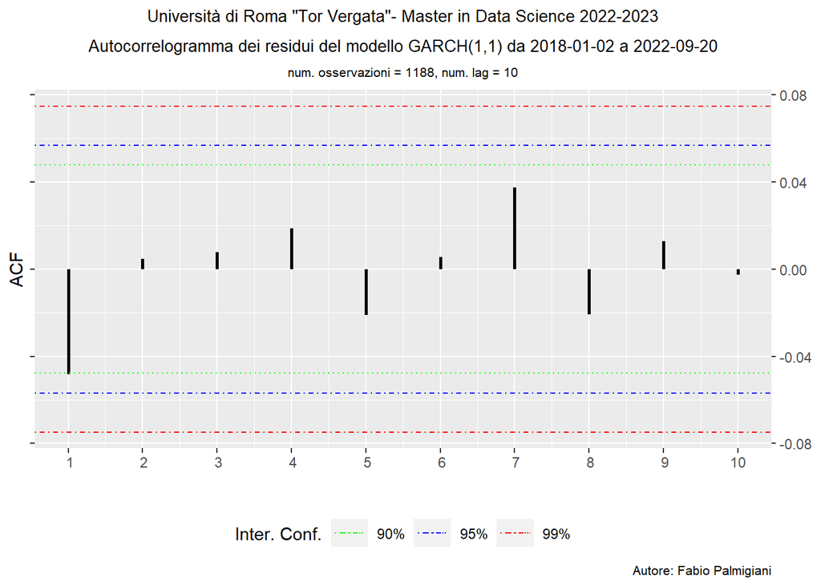

```r
#Autocorrelogramma dei residui del modello GARCH(1,1)
y <- na.omit(GARCH_Adj.Close.log.ret_sel$residuals)
T<- length(y)
maxlag <- ceiling(min(10,T/4))
Aut_Fun_y <- acf(y, lag.max=maxlag, type="correlation", plot=FALSE)
ci_90 <- qnorm((1+0.90)/2)/sqrt(T)
ci_95 <- qnorm((1+0.95)/2)/sqrt(T)
ci_99 <- qnorm((1+0.99)/2)/sqrt(T)
Plot_Aut_Fun_y <- data.frame(lag=Aut_Fun_y$lag, acf=Aut_Fun_y$acf)
First_Day <- as.character(Data_df_train$Date[1])
Last_Day <- as.character(Data_df_train$Date[T])
title_content <- bquote(atop("Università di Roma \"Tor Vergata\"- Master in Data Science 2022-2023",
                             paste("Autocorrelogramma dei residui del modello GARCH(1,1) da ", .(First_Day)," a ", .(Last_Day))))
subtitle_content <- bquote(paste("num. osservazioni = ", .(T),", num. lag = ", .(maxlag)))
caption_content <-"Autore: Fabio Palmigiani"
x_name <- bquote("lags")
x_breaks <- Aut_Fun_y$lag
x_labs <- format(x_breaks, scientific=FALSE)
ggplot(Plot_Aut_Fun_y, aes(x=lag, y=acf))+ geom_segment(aes(x=lag, y=rep(0,length(lag)), xend=lag, yend=acf), linewidth=1, col="black") +
  geom_hline(aes(yintercept=-ci_90, color="CI_90"), show.legend=TRUE, lty=3) +
  geom_hline(aes(yintercept=ci_90, color="CI_90"), lty=3) +
  geom_hline(aes(yintercept=ci_95, color="CI_95"), show.legend=TRUE, lty=4)+
  geom_hline(aes(yintercept=-ci_95, color="CI_95"), lty=4) +
  geom_hline(aes(yintercept=-ci_99, color="CI_99"), show.legend=TRUE, lty=4) +
  geom_hline(aes(yintercept=ci_99, color="CI_99"), lty= 4) +
  scale_x_continuous(name="", breaks=x_breaks, label=x_labs) +
  scale_y_continuous(name="ACF", breaks=waiver(), labels=NULL, sec.axis=sec_axis(~., breaks=waiver(), labels=waiver())) +
  scale_color_manual(name="Inter. Conf.", labels=c("90%","95%","99%"), values=c(CI_90="green", CI_95="blue", CI_99= "red")) +
  ggtitle(title_content) + labs(subtitle=subtitle_content, caption=caption_content) +
  theme(plot.title=element_text(hjust = 0.5, size = 10),
        plot.subtitle=element_text(hjust =0.5, size =8),
        plot.caption = element_text(hjust = 1.0, size =8),
        legend.key.width = unit(0.8,"cm"), legend.position="bottom")
```

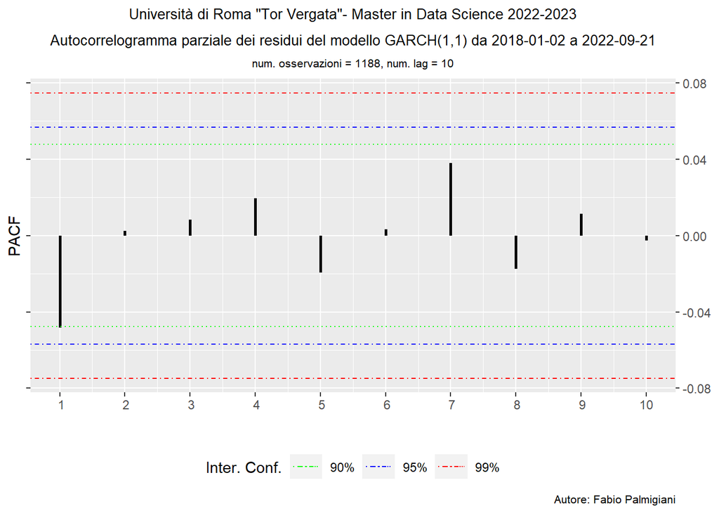

```r
#Autocorrelogramma parziale dei residui del modello GARCH(1,1)
y <- na.omit(GARCH_Adj.Close.log.ret_sel$residuals)
T<- length(y)
maxlag <- ceiling(min(10,T/4))
Part_Aut_Fun_y <- pacf(y, lag.max=maxlag, type="correlation", plot=FALSE)
ci_90 <- qnorm((1+0.90)/2)/sqrt(T)
ci_95 <- qnorm((1+0.95)/2)/sqrt(T)
ci_99 <- qnorm((1+0.99)/2)/sqrt(T)
Plot_Part_Aut_Fun_y <- data.frame(lag=Part_Aut_Fun_y$lag, pacf=Part_Aut_Fun_y$acf)
First_Day <- as.character(Data_df_train$Date[1])
Last_Day <- as.character(Data_df_train$Date[nrow(Data_df_train)])
x_name <- bquote("lags")
x_breaks <- Aut_Fun_y$lag
x_labs <- format(x_breaks, scientific=FALSE)
title_content <- bquote(atop("Università di Roma \"Tor Vergata\"- Master in Data Science 2022-2023",
                             paste("Autocorrelogramma parziale dei residui del modello GARCH(1,1) da ", .(First_Day)," a ", .(Last_Day))))
subtitle_content <- bquote(paste("num. osservazioni = ", .(T),", num. lag = ", .(maxlag)))
caption_content <-"Autore: Fabio Palmigiani"
ggplot(Plot_Part_Aut_Fun_y, aes(x=lag, y=pacf)) + geom_segment(aes(x=lag, y=rep(0,length(lag)), xend=lag, yend=pacf), size =1, col="black") +
  geom_hline(aes(yintercept=-ci_90, color="CI_90"), show.legend =TRUE, lty=3) +
  geom_hline(aes(yintercept=ci_90, color="CI_90"), lty=3) +
  geom_hline(aes(yintercept=ci_95, color="CI_95"), show.legend =TRUE, lty=4) +
  geom_hline(aes(yintercept=-ci_95, color="CI_95"), lty=4) +
  geom_hline(aes(yintercept=-ci_99, color="CI_99"), show.legend =TRUE, lty=4) +
  geom_hline(aes(yintercept=ci_99, color="CI_99"), lty=4) +
  scale_x_continuous(name="", breaks=x_breaks, label=x_labs) +
  scale_y_continuous(name= "PACF", breaks=waiver(), labels=NULL, sec.axis = sec_axis(~., breaks=waiver(), labels=waiver())) +
  scale_color_manual(name= "Inter. Conf.", labels=c("90%", "95%", "99%"), values=c(CI_90="green", CI_95="blue", CI_99= "red")) +
  ggtitle(title_content) + labs(subtitle=subtitle_content, caption=caption_content) +
  theme(plot.title=element_text(hjust =0.5, size =10),
        plot.subtitle=element_text(hjust =0.5, size =8),
        plot.caption = element_text(hjust = 1.0, size =8),
        legend.key.width = unit(0.8, "cm"), legend.position= "bottom")
```

In entrambi i casi non ci sono picchi che superano la banda del 90%, quindi è stato possibile affermare che i residui non siano autocorrelati. Per confermare questa tesi si è effettuato anche il test di Ljung–Box

```r
y <- na.omit(GARCH_Adj.Close.log.ret_sel$residuals)
T <- length(y)
maxlag <- ceiling(min(10,T/4))
LjungBoxTest(y, lag.max=maxlag, k=0, StartLag=1, SquaredQ=FALSE)
```

```
##   m   Qm    pvalue
##   1 0.03 0.8702147
##   2 0.10 0.9509552
##   3 0.51 0.9159470
##   4 1.05 0.9025444
##   5 1.08 0.9556298
##   6 2.77 0.8374829
##   7 3.29 0.8570214
##   8 3.49 0.8999797
##   9 3.50 0.9412146
##  10 3.53 0.9662229
```

e, come ci si aspettava, i p-values sono tutti maggiori di 0.05, anzi rasentano addirittura l’1. Quindi è stato possibile affermare che i residui sono non autocorrelati.

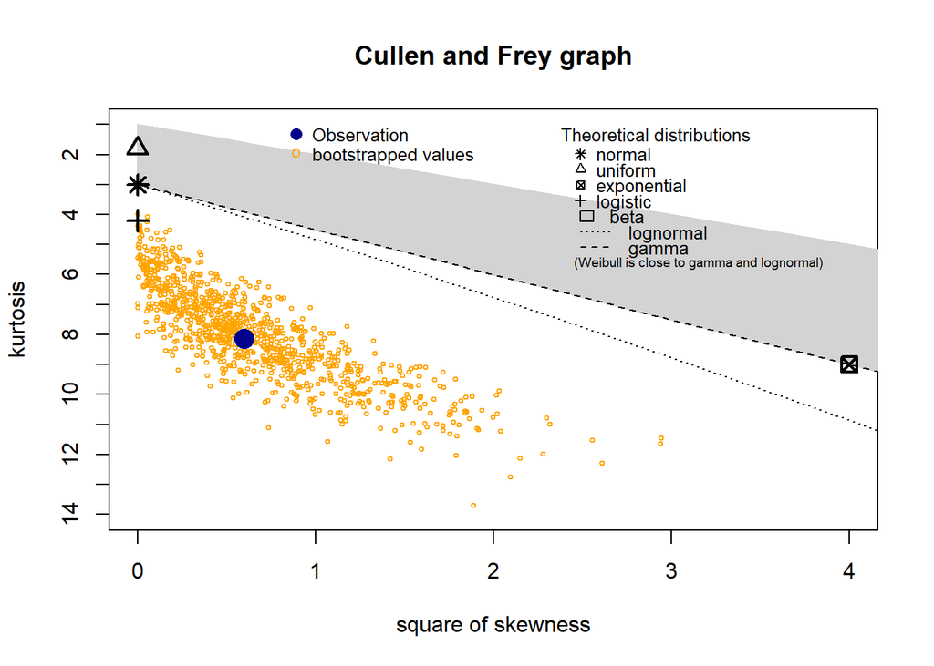

```
## summary statistics
## ------
## min:  -7.002433   max:  4.561457
## median:  0.03917878
## mean:  0.01180525
## sample sd:  0.9996246
## sample skewness:  -0.7740093
## sample kurtosis:  8.148922
```

```r
z <- as.vector(na.omit(GARCH_Adj.Close.log.ret_sel$residuals))
descdist(z, discrete = FALSE, method ="sample", graph = TRUE, boot= 1000)
```

Istogramma e la funzione di densità empirica dei residui standardizzati:

```r
#istogramma
z_st <- (1/sd(z))*as.vector(z-mean(z))
z_st_qemp <- qemp(ppoints(z_st), z_st)
z_st_demp <- demp(z_st_qemp, z_st)
z_st_pemp <- pemp(z_st_qemp, z_st)
```

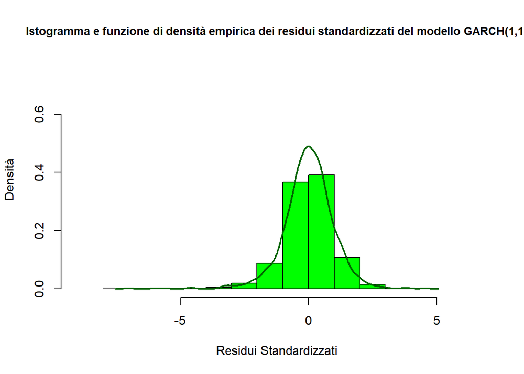

```r
x <- z_st_qemp
y_d <- z_st_demp
y_p <- z_st_pemp
hist(z_st, col="green", border="black", xlim=c(x[1]-2.0, x[length(x)]+2.0),
                     ylim=c(0, y_d[length(y_d)]+ 0.75), freq=FALSE, main="Istogramma e funzione di densità empirica dei residui standardizzati del modello GARCH(1,1)",
                     xlab="Residui Standardizzati",
                     ylab="Densità",
                     cex.main=0.9)
lines(density(z_st), lwd=2, col="darkgreen")
```

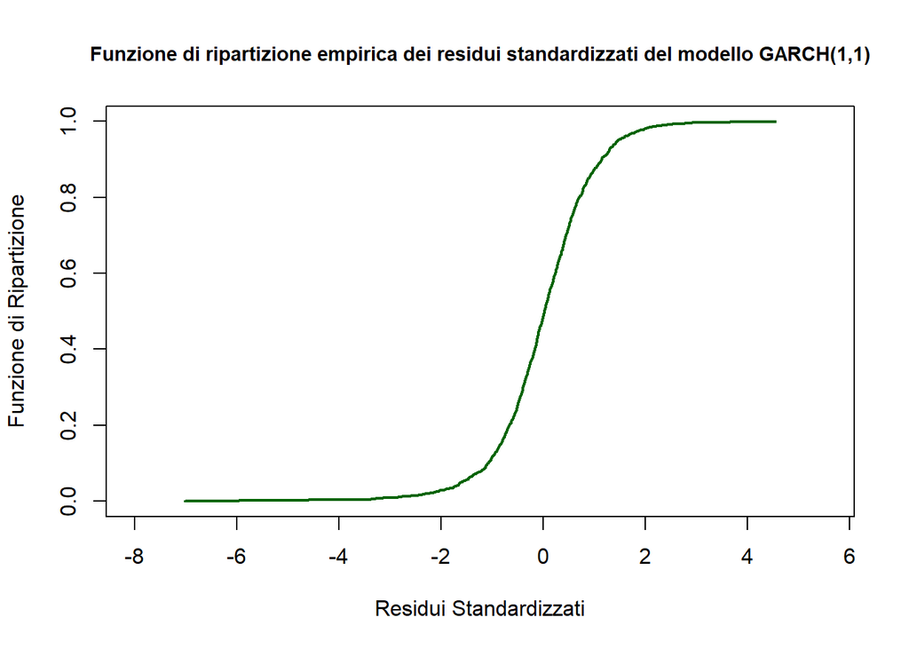

```r
# funzione di distrtibuzione empirica
ecdfPlot(z_st, discrete=TRUE, prob.method="emp.probs", type="s", plot.it=TRUE, add=FALSE, ecdf.col="darkgreen", ecdf.lwd=2, ecdf.lty=1, curve.fill=FALSE,
         main="Funzione di ripartizione empirica dei residui standardizzati del modello GARCH(1,1)",
         xlab="Residui Standardizzati",
         ylab="Funzione di Ripartizione",
         xlim=c(x[1]-1.0, x[length(x)]+1.0),cex.main=0.9)
```

Siccome i grafici sembrano confermare l’ipotesi, sono stati stimati i parametri della distribuzione di student teorica e la si è confrontata con quella empirica dei residui.

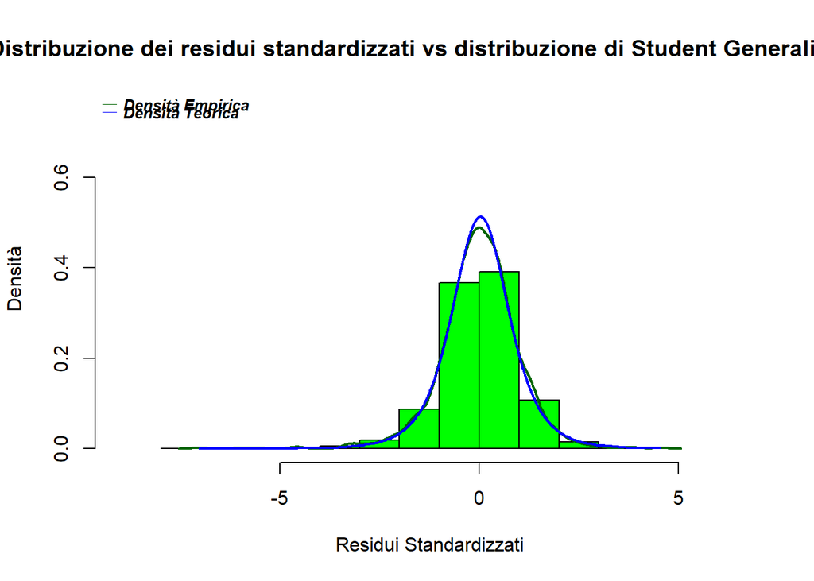

```r
dt_ls <- function(x, m, s, df)  1/s*dt((x-m)/s, df)
pt_ls <- function(q, m, s, df)  pt((q-m)/s, df)
qt_ls <- function(p, m, s, df)  qt(p, df)*s+m
rt_ls <- function(n, m, s, df)  rt(n,df)*s+m

fitdistr_t_ls <- fitdistr(z_st, dt_ls, start=list(m=0, s=sqrt(1/3), df=3), lower=c(0,0,2))

m <- as.numeric(fitdistr_t_ls$estimate[1])
s <- as.numeric(fitdistr_t_ls$estimate[2])
df <- as.numeric(fitdistr_t_ls$estimate[3])

# Grafico che confronta la distribuzione di student teorica con quella empiria dei residui
hist(z_st, col="green", border="black", xlim=c(x[1]-2.0, x[length(x)]+2.0), ylim=c(0, y_d[length(y_d)]+0.75),
     freq=FALSE, main="Distribuzione dei residui standardizzati vs distribuzione di Student Generalizzata",
     xlab="Residui Standardizzati", ylab="Densità")
lines(density(z_st), lwd=2, col="darkgreen")
lines(x, dt_ls(x, m=m, s=s, df=df), lwd=2, col="blue")
legend("topleft", legend=c("Densità Empirica", "Densità Teorica"), col=c("darkgreen", "blue"),
       lty=1, lwd=0.1, cex=0.8, x.intersp=0.50, y.intersp=0.40, text.width=2, seg.len=1, text.font=4, box.lty=0,
       inset=-0.01, bty="n")
```

Come si evince dal grafico, le densità delle due distribuzioni sembrano quasi combaciare perfettamente.

## Previsione

Per poter effettuare la previsione, inizialmente sono state generate 1000 serie utilizzando un seed diverso ogni volta per generare valori casuali della distribuzione di student stimata in precedenza. Una volta salvate queste serie all’interno di una matrice, sono stati calcolati i quantili e la previsione puntuale, definita come media di tutte le previsioni puntuali, ad ogni tempo t.

```r
# generiamo 1000 serie
n <-1000
T<- TstS_length
y_pred_distrname_mat <- matrix(NA, nrow=T, ncol = n)
sigma <- rep(NA, length.out=T)
y <- Data_df_train$Adj.Close.log[c(1:TrnS_length)]
prev_adj_close <- matrix(NA, nrow=T, ncol = n)
x <- rep(NA, length.out=T)

for(k in 1:n){
  set.seed(k)

  w <- rt_ls(T, m=m, s=s, df=df)
  x_0 <- CSCO_df$CSCO.Adjusted.log.ret[TrnS_length-1]
  sigma_0 <- sd(CSCO_df$CSCO.Adjusted.log.ret[c(1:TrnS_length)], na.rm=TRUE)
  sigma_1 <- sqrt(alpha_0 + alpha_1*(x_0)^2 + beta_1*(sigma_0)^2)
  x_1 <- CSCO_df$CSCO.Adjusted.log.ret[TrnS_length]
  sigma[1] <- sqrt(alpha_0 + alpha_1*(x_1)^2 + beta_1*((sigma_1)^2))
  x[1] <- sigma[1]*w[1]

  for(t in 2:T){
    sigma[t] <- sqrt(alpha_0 + alpha_1*x[t-1]^2 + beta_1* (sigma[t-1]^2))
    x[t] <- sigma[t]*w[t]
  }

  y_pred_distrname_mat[,k] <- x
  prev_adj_close[1,k] =  exp(exp(log(y[TrnS_length]) - mean(y_pred_distrname_mat[,k])))
  for (t in 2:T){
    prev_adj_close[t,k] =  exp(exp(log(log(prev_adj_close[t-1,k]) - mean(y_pred_distrname_mat[t,k]))))
  }
}
```

```r
# calcolo quantili
real_path <- CSCO_df$CSCO.Adjusted.log.ret[c((TrnS_length+1):DtS_length)]
Q = matrix(NA, nrow=T, ncol=9)
Q[,1] <- c(real_path, rep(NA,T-length(real_path)))
for(t in 1:T){
  Q[t,2] <- mean(y_pred_distrname_mat[t,1:n])
  Q[t,3:9] <- quantile(y_pred_distrname_mat[t,1:n], probs=c(0.50, 0.005, 0.025, 0.05, 0.95, 0.975, 0.995))
}
```

Primo plot della previsione dei rendimenti logaritmici

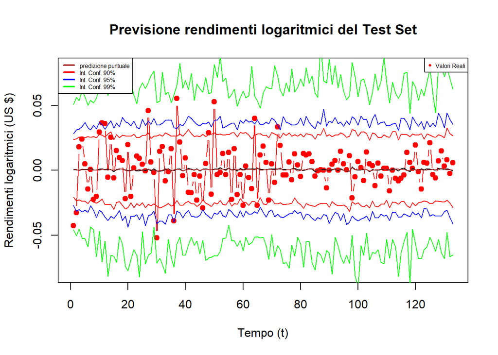

```r
plot(Q[,1], type ="b", pch=19, col="red", ylim=c(-0.08,0.08),
     xlab="Tempo (t)",
     ylab="Rendimenti logaritmici (US $)"
     ,main="Previsione rendimenti logaritmici del Test Set")
lines(Q[,2], type = "l", lty=1, col="black")
lines(Q[,3], type = "l", lty=1, col="brown")
lines(Q[,4], type = "l", lty=1, col="green")
lines(Q[,9], type = "l", lty=1, col="green")
lines(Q[,5], type = "l", lty=1, col="blue")
lines(Q[,8], type = "l", lty=1, col="blue")
lines(Q[,6], type = "l", lty=1, col="red")
lines(Q[,7], type = "l", lty=1, col="red")

legend(x ="topleft", legend = c("predizione puntuale","Int. Conf. 90%","Int. Conf. 95%","Int. Conf. 99%"),
       lty = c(1,1,1,1),
       cex= 0.5, col = c("brown","red","blue","green"),
       lwd = 2)
legend(x ="topright", legend ="Valori Reali",
       pch =16, cex=0.5, col ="red")
```

A questo punto si è effettuata la trasformazione inversa per ottenere la previsione dei prezzi.

```r
real_path <- Original_Data$Adj.Close[c((TrnS_length+1):DtS_length)]
Q_adj_close = matrix(NA, nrow=T, ncol=9)
Q_adj_close[,1] <- c(real_path, rep(NA,T-length(real_path)))
for(t in 1:T){
  Q_adj_close[t,2] <- mean(prev_adj_close[t,1:n])
  Q_adj_close[t,3:9] <- quantile(prev_adj_close[t,1:n], probs=c(0.50, 0.005, 0.05, 0.10, 0.90, 0.95, 0.995))
}

y_lim_sup = max(Q_adj_close[,9])
y_lim_inf = min(Q_adj_close[,4])
```

è stato generato anche in questo caso un grafico esplicativo

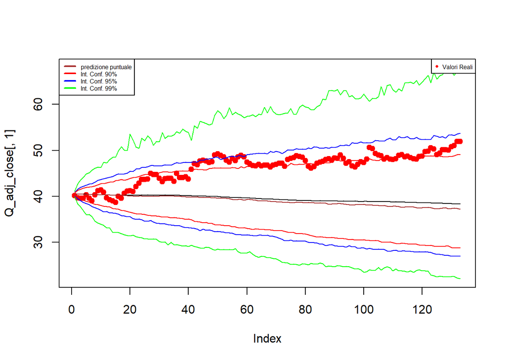

```r
plot(Q_adj_close[,1], type = "b", pch=19, col="red", ylim=c(y_lim_inf, y_lim_sup))
lines(Q_adj_close[,2], type = "l", lty=1, col="black")
lines(Q_adj_close[,3], type = "l", lty=1, col="brown")
lines(Q_adj_close[,4], type = "l", lty=1, col="green")
lines(Q_adj_close[,9], type = "l", lty=1, col="green")
lines(Q_adj_close[,5], type = "l", lty=1, col="blue")
lines(Q_adj_close[,8], type = "l", lty=1, col="blue")
lines(Q_adj_close[,6], type = "l", lty=1, col="red")
lines(Q_adj_close[,7], type = "l", lty=1, col="red")

legend(x="topleft", legend = c("predizione puntuale","Int. Conf. 90%","Int. Conf. 95%","Int. Conf. 99%"),
       lty = c(1,1,1,1), cex=0.5,
       col = c("brown", "red", "blue", "green"), lwd = 2)
legend(x ="topright", legend = "Valori Reali", pch = 16, cex=0.5, col = "red")
```

Come si nota la previsione si stabilizza a cavallo della banda supriore del 90%, con un’inpennata finale che potrebbe anche indurre a pensare che vada fuori dal 95%.

In conclusione, è stata rappresentata la serie originale, con le previsioni per il test set.

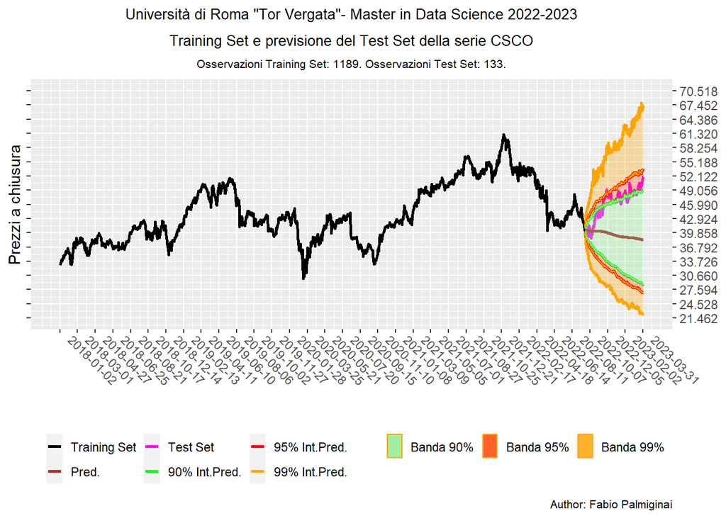

```r
CSCO_p_prev <- c(rep(NA,TrnS_length),Q_adj_close[,2])
CSCO_q99_up <- c(rep(NA,TrnS_length),Q_adj_close[,9])
CSCO_q99_low <- c(rep(NA,TrnS_length),Q_adj_close[,4])
CSCO_q95_up <- c(rep(NA,TrnS_length),Q_adj_close[,8])
CSCO_q95_low <- c(rep(NA,TrnS_length),Q_adj_close[,5])
CSCO_q90_up <- c(rep(NA,TrnS_length),Q_adj_close[,7])
CSCO_q90_low <- c(rep(NA,TrnS_length),Q_adj_close[,6])

CSCO_pred_full_df <- Original_Data[c("t","Date","Adj.Close")]

CSCO_pred_full_df <- add_column(CSCO_pred_full_df,
                                CSCO_point_for=CSCO_p_prev,
                                CSCO_q99_up=CSCO_q99_up,
                                CSCO_q99_low=CSCO_q99_low,
                                CSCO_q95_up=CSCO_q95_up,
                                CSCO_q95_low=CSCO_q95_low,
                                CSCO_q90_up=CSCO_q90_up,
                                CSCO_q90_low=CSCO_q90_low)

Data_df <- CSCO_pred_full_df
length <- nrow(Data_df)
T <- TrnS_length
First_Day <- CSCO_pred_full_df$Date[1]
Last_Day <- CSCO_pred_full_df$Date[length]
title_content <- bquote(atop("Università di Roma \"Tor Vergata\"- Master in Data Science 2022-2023",
                             paste("Training Set e previsione del Test Set della serie CSCO")))
subtitle_content <- bquote(paste("Osservazioni Training Set: ", .(TrnS_length),". Osservazioni Test Set: ", .(TstS_length),"."))
caption_content <-"Author: Fabio Palmiginai"
x_name <- bquote("")
x_breaks_num <- 33
x_breaks_low <- Data_df$t[1]
x_breaks_up <- Data_df$t[length]
x_binwidth <- floor((x_breaks_up-x_breaks_low)/x_breaks_num)
x_breaks <- seq(from=x_breaks_low, to=x_breaks_up, by=x_binwidth)
if((max(x_breaks)-x_breaks_up)>x_binwidth/2)
  {x_breaks <- c(x_breaks,x_breaks_up)}
x_labs <- paste(Data_df$Date[x_breaks])
J <-0
x_lims <- c(x_breaks_low-J*x_binwidth, x_breaks_up+J*x_binwidth)
y_name <- bquote("Prezzi a chiusura")
y_breaks_num <-15
y_max <- max(na.omit(Data_df$Adj.Close),na.omit(Data_df$CSCO_q99_up))
y_min <- min(na.omit(Data_df$Adj.Close),na.omit(Data_df$CSCO_q99_low))
y_binwidth <- round((y_max-y_min)/y_breaks_num, digits=3)
y_breaks_low <- floor(y_min/y_binwidth)*y_binwidth
y_breaks_up <- ceiling(y_max/y_binwidth)*y_binwidth
y_breaks <- round(seq(from=y_breaks_low, to=y_breaks_up, by=y_binwidth),digits=3)
y_labs <- format(y_breaks, scientific=FALSE)
K <-0
y_lims <- c((y_breaks_low-K*y_binwidth), (y_breaks_up+K*y_binwidth))
line_black <- bquote("Training Set")
line_magenta <- bquote("Test Set")
line_brown <- bquote("Pred.")
line_green <- bquote("90% Int.Pred.")
line_red <- bquote("95% Int.Pred.")
line_orange <- bquote("99% Int.Pred.")
leg_line_labs <- c(line_black, line_brown, line_magenta, line_green, line_red,line_orange)
leg_line_breaks <- c("line_black","line_brown","line_magenta","line_green","line_red","line_orange")
leg_line_cols <- c("line_black" ="black", "line_brown"="brown","line_magenta"="magenta","line_green"="green","line_red"="red","line_orange"="orange")
fill_g <- bquote("Banda 90%")
fill_r <- bquote("Banda 95%")
fill_o <- bquote("Banda 99%")
leg_fill_labs <- c( fill_g, fill_r,fill_o)
leg_fill_breaks <- c("fill_g","fill_r","fill_o")
leg_fill_cols <- c("fill_g" ="lightgreen","fill_r"="orangered","fill_o"="orange")
leg_col_labs <- leg_line_labs
leg_col_breaks <- leg_line_breaks
leg_col_cols <- leg_line_cols
y_pred_lp <- ggplot(Data_df, aes(x=t)) +
  geom_line(data=subset(Data_df, Data_df$t <= t[T+1]), aes(y=Adj.Close, color="line_black"),
            linetype="solid", alpha=1, size=1, group=1) +
  geom_line(data=subset(Data_df, Data_df$t >= t[T+1]), aes(y=Adj.Close, color="line_magenta"),
            linetype="solid", alpha=1, size=1, group=1) +
  geom_line(data=subset(Data_df, Data_df$t >= t[T+1]), aes(y=CSCO_point_for, colour="line_brown"),
            linetype="solid", alpha=1, size=1) +
  geom_line(data=subset(Data_df, Data_df$t >= t[T+1]), aes(y=CSCO_q99_low, colour="line_orange"),
            linetype="solid", alpha=1, size=1) +
  geom_line(data=subset(Data_df, Data_df$t >= t[T+1]), aes(y=CSCO_q99_up, colour="line_orange"),
            linetype="solid", alpha=1, size=1) +
  geom_line(data=subset(Data_df, Data_df$t >= t[T+1]), aes(y=CSCO_q95_low, colour="line_red"),
            linetype="solid", alpha=1, size=1) +
  geom_line(data=subset(Data_df, Data_df$t >= t[T+1]), aes(y=CSCO_q95_up, colour="line_red"),
            linetype="solid", alpha=1, size=1) +
  geom_line(data=subset(Data_df, Data_df$t >= t[T+1]), aes(y=CSCO_q90_low, colour="line_green"),
            linetype="solid", alpha=1, size=1) +
  geom_line(data=subset(Data_df, Data_df$t >= t[T+1]), aes(y=CSCO_q90_up, colour="line_green"),
            linetype="solid", alpha=1, size=1) +
  geom_ribbon(data=subset(Data_df, Data_df$t >= t[T+1]),
              alpha=0.3, colour=  "orangered", aes(ymin=CSCO_q95_low, ymax=CSCO_q90_low, fill="fill_r")) +
  geom_ribbon(data=subset(Data_df, Data_df$t >= t[T+1]),
              alpha=0.3, colour="orangered", aes(ymin=CSCO_q90_up, ymax=CSCO_q95_up, fill="fill_r")) +
  geom_ribbon(data=subset(Data_df, Data_df$t >= t[T+1]),
              alpha=0.3, colour="lightgreen", aes(ymin=CSCO_q90_low, ymax=CSCO_q90_up, fill="fill_g")) +
  geom_ribbon(data=subset(Data_df, Data_df$t >= t[T+1]),
              alpha=0.3, colour="orange", aes(ymin=CSCO_q99_low, ymax=CSCO_q95_low, fill="fill_o")) +
  geom_ribbon(data=subset(Data_df, Data_df$t >= t[T+1]),
              alpha=0.3, colour="orange", aes(ymin=CSCO_q95_up, ymax=CSCO_q99_up, fill="fill_o")) +
  scale_x_continuous(name=x_name, breaks=x_breaks, labels=x_labs, limits=x_lims) +
  scale_y_continuous(name=y_name, breaks=y_breaks, labels=NULL, limits=y_lims, sec.axis= sec_axis(~., breaks=y_breaks, labels=y_labs)) +
  ggtitle(title_content) + labs(subtitle=subtitle_content, caption=caption_content) + guides(linetype="none", shape="none") +
  scale_colour_manual(name="", labels=leg_line_labs, values=leg_line_cols, breaks=leg_line_breaks) +
  scale_fill_manual(name="", labels=leg_fill_labs, values=leg_fill_cols, breaks=leg_fill_breaks) +
  guides(colour=guide_legend(order=1), fill=guide_legend(order=2)) +
  theme(plot.title=element_text(hjust =0.5, size=10),
        plot.subtitle=element_text(hjust =0.5, size =8),
        plot.caption = element_text(hjust =1.0, size =8 ),
        axis.text.x = element_text(angle=-45, vjust=1, hjust=-0.3),
        legend.key.width = unit(0.4,"cm"), legend.position="bottom")
plot(y_pred_lp)
```

## Conclusioni

Cosa da notare è che, a causa dell’elevata volatilità del titolo, le bande di previsione sono piuttosto ampie.

Come detto già in precedenza si nota che il test set è a cavallo della soglia del 90% per poi impennarsi alla fine restando perà sempre all’interno del 95%. Questo forse è frutto del fatto che il modello Garch non convergeva.

Si conclude quindi con il fatto che il modello potrebbe essere migliorato.